# The Science of Decisions Project (Statistics)

Raju Singh

September 1, 2017

# Abstract

In this paper I use R to conduct a t-test on stroop effect.

# Reading the CSV

```
##    Congruent Incongruent
## 1     12.079      19.278
## 2     16.791      18.741
## 3      9.564      21.214
## 4      8.630      15.687
## 5     14.669      22.803
## 6     12.238      20.878
## 7     14.692      24.572
## 8      8.987      17.394
## 9      9.401      20.762
## 10    14.480      26.282
## 11    22.328      24.524
## 12    15.298      18.644
## 13    15.073      17.510
## 14    16.929      20.330
## 15    18.200      35.255
## 16    12.130      22.158
## 17    18.495      25.139
## 18    10.639      20.429
## 19    11.344      17.425
## 20    12.369      34.288
## 21    12.944      23.894
## 22    14.233      17.960
## 23    19.710      22.058
## 24    16.004      21.157
```

### Q1. What is our independent variable? What is our dependent variable?

INDEPENDENT - Word Condition (Congruent or Incongruent)

DEPENDENT - Response Time in seconds

### Q2. What is an appropriate set of hypotheses for this task? What kind of statistical test do you expect to perform? Justify your choices.

Ho - Null Hypothesis: ( μi - μc = 0 ) There is no significant difference in the population average response time in viewing the congruent(c) words vs viewing the incongruent(i) words.

Ha - Alternative Hypothesis: ( μi - μc ≠ 0 ) There is a significant difference, positive or negative, in the population average response times.

The Dependent Samples t-Test is the appropriate statistical test as the same subjects are assigned two different conditions. The different conditions are dependent because, in theory, by doing the first test you have some practice doing it and you might have an unfair advantage due to this learning effect in doing the similar type of test second. In addition, we don’t have any population parameters provided (so a z-test would not be appropriate here).

### Q3. Report some descriptive statistics regarding this dataset. Include at least one measure of central tendency and at least one measure of variability.

Average time of Congruent group is 14.051, and average time of Incongruent group is 22.016, the latter is larger. The deviances are 3.559 and 4.797. The times in Incongruent group vary more.

### Q4. Provide one or two visualizations that show the distribution of the sample data. Write one or two sentences noting what you observe about the plot or plots.

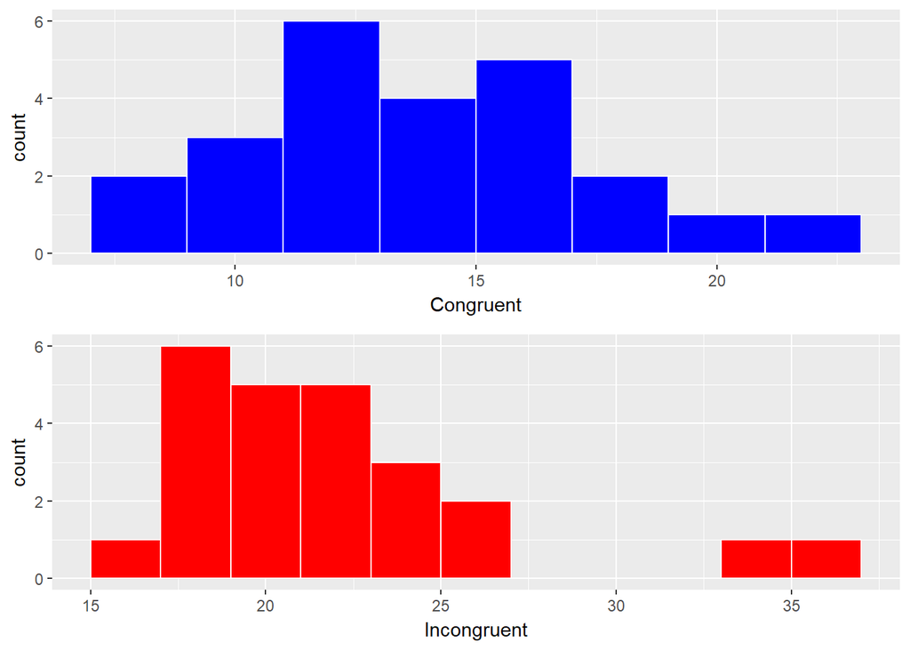

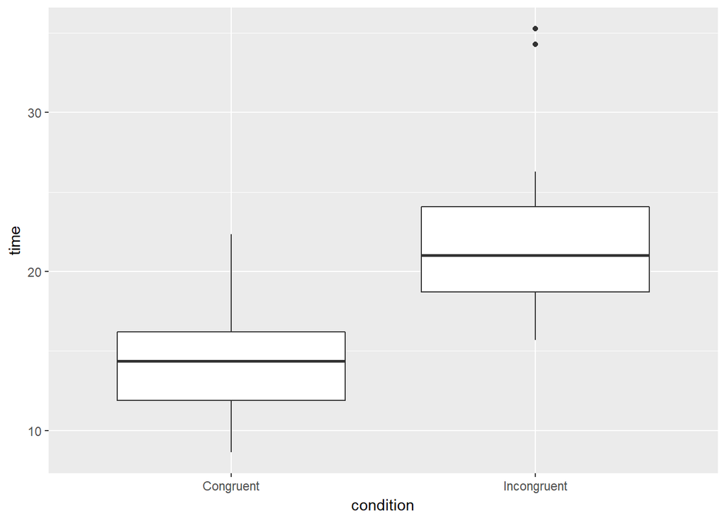

From histogram of Congruent time and Incongruent time we can see that the data is approximately normally distributed, from box plot we can see that most time in Incongruent group is greater than time in Congruent group.

## Conclusion

Although we get conclusion “Average of time population in Incongruent group is greater than average of time population in Congruent group”, actually we don’t know weather words help people to recognize color in Congruent group, or interfere people to recognize color in Incongruent group, or both. It would better have a neutral group to help us decide.